# Midterm 2 W25

Bryan Correa Gonzalez

2025-03-04

## Instructions

Before starting the exam, you need to follow the instructions in `02_midterm2_cleaning.Rmd` to clean the data. Once you have cleaned the data and produced the `heart.csv` file, you can start the exam.

Answer the following questions and complete the exercises in RMarkdown. Please embed all of your code and push your final work to your repository. Your code must be organized, clean, and run free from errors. Remember, you must remove the `#` for any included code chunks to run. Be sure to add your name to the author header above.

Your code must knit in order to be considered. If you are stuck and cannot answer a question, then comment out your code and knit the document. You may use your notes, labs, and homework to help you complete this exam. Do not use any other resources- including AI assistance or other students’ work.

Don’t forget to answer any questions that are asked in the prompt! Each question must be coded; it cannot be answered by a sort in a spreadsheet or a written response.

All plots should be clean, with appropriate labels, and consistent aesthetics. Poorly labeled or messy plots will receive a penalty. Your plots should be in color and look professional!

Be sure to push your completed midterm to your repository and upload the document to Gradescope. This exam is worth 30 points.

## Load the libraries

You may not use all of these, but they are here for convenience.

```r
library("tidyverse")
library("janitor")
library("ggthemes")
library("RColorBrewer")
library("paletteer")
```

## Load the data

These data are a modified version of the Statlog (Heart) database on heart disease from the [UCI Machine Learning Repository](https://archive.ics.uci.edu/dataset/145/statlog+heart). The data are also available on [Kaggle](https://www.kaggle.com/datasets/ritwikb3/heart-disease-statlog/data).

You will need the descriptions of the variables to answer the questions. Please reference `03_midterm2_descriptions.Rmd` for details.

Run the following to load the data.

```r
heart <- read_csv("data/heart.csv")
```

## Questions

Problem 1. (1 point) Use the function of your choice to provide a data summary.

```r
glimpse(heart)
```

```
## Rows: 270
## Columns: 14
## $ age      <dbl> 70, 67, 57, 64, 74, 65, 56, 59, 60, 63, 59, 53, 44, 61, 57, 7…
## $ gender   <chr> "male", "female", "male", "male", "female", "male", "male", "…
## $ cp       <chr> "asymptomatic", "non_anginal_pain", "atypical_angina", "asymp…
## $ trestbps <dbl> 130, 115, 124, 128, 120, 120, 130, 110, 140, 150, 135, 142, 1…
## $ chol     <dbl> 322, 564, 261, 263, 269, 177, 256, 239, 293, 407, 234, 226, 2…
## $ fbs      <lgl> FALSE, FALSE, FALSE, FALSE, FALSE, FALSE, TRUE, FALSE, FALSE,…
## $ restecg  <chr> "left_ventricular_hypertrophy", "left_ventricular_hypertrophy…
## $ thalach  <dbl> 109, 160, 141, 105, 121, 140, 142, 142, 170, 154, 161, 111, 1…
## $ exang    <chr> "no", "no", "no", "yes", "yes", "no", "yes", "yes", "no", "no…
## $ oldpeak  <dbl> 2.4, 1.6, 0.3, 0.2, 0.2, 0.4, 0.6, 1.2, 1.2, 4.0, 0.5, 0.0, 0…
## $ slope    <chr> "flat", "flat", "upsloping", "flat", "upsloping", "upsloping"…
## $ ca       <dbl> 3, 0, 0, 1, 1, 0, 1, 1, 2, 3, 0, 0, 0, 2, 1, 0, 2, 0, 0, 0, 2…
## $ thal     <chr> "normal", "reversable_defect", "reversable_defect", "reversab…
## $ target   <chr> "disease", "no_disease", "disease", "no_disease", "no_disease…
```

```r
summary(heart)
```

```
##       age           gender               cp               trestbps
##  Min.   :29.00   Length:270         Length:270         Min.   : 94.0
##  1st Qu.:48.00   Class :character   Class :character   1st Qu.:120.0
##  Median :55.00   Mode  :character   Mode  :character   Median :130.0
##  Mean   :54.43                                         Mean   :131.3
##  3rd Qu.:61.00                                         3rd Qu.:140.0
##  Max.   :77.00                                         Max.   :200.0
##       chol          fbs            restecg             thalach
##  Min.   :126.0   Mode :logical   Length:270         Min.   : 71.0
##  1st Qu.:213.0   FALSE:230       Class :character   1st Qu.:133.0
##  Median :245.0   TRUE :40        Mode  :character   Median :153.5
##  Mean   :249.7                                      Mean   :149.7
##  3rd Qu.:280.0                                      3rd Qu.:166.0
##  Max.   :564.0                                      Max.   :202.0
##     exang              oldpeak        slope                 ca
##  Length:270         Min.   :0.00   Length:270         Min.   :0.0000
##  Class :character   1st Qu.:0.00   Class :character   1st Qu.:0.0000
##  Mode  :character   Median :0.80   Mode  :character   Median :0.0000
##                     Mean   :1.05                      Mean   :0.6704
##                     3rd Qu.:1.60                      3rd Qu.:1.0000
##                     Max.   :6.20                      Max.   :3.0000
##      thal              target
##  Length:270         Length:270
##  Class :character   Class :character
##  Mode  :character   Mode  :character
##
##
##
```

Problem 2. (1 point) Let’s explore the demographics of participants included in the study. What is the number of males and females? Show this as a table.

The number of males is 183. The number of females is 87.

```r
heart %>%
  count(gender) %>%
  tibble()
```

```
## # A tibble: 2 × 2
##   gender     n
##   <chr>  <int>
## 1 female    87
## 2 male     183
```

Problem 3. (2 points) What is the average age of participants by gender? Show this as a table.

The average of males is 53.8 years. The average age of females is 55.6 years.

```r
heart %>%
  select(gender, age) %>%
  group_by(gender) %>%
  summarize(mean_n_by_gender = mean(age)) %>%
  tibble()
```

```
## # A tibble: 2 × 2
##   gender mean_n_by_gender
##   <chr>             <dbl>
## 1 female             55.7
## 2 male               53.8
```

Problem 4. (1 point) Among males and females, how many have/do not have heart disease? Show this as a table, grouped by gender.

Among males 83 do not have heart disease (no_disease) while 100 males do have heart disease (heart_disease). Among females, 67 do not have heart disease (no_disease) while 20 females do have hear disease (heart_disease).

```r
heart %>%
  select(gender, target) %>%
  group_by(gender)%>%
  count(target)
```

```
## # A tibble: 4 × 3
## # Groups:   gender [2]
##   gender target         n
##   <chr>  <chr>      <int>
## 1 female disease       20
## 2 female no_disease    67
## 3 male   disease      100
## 4 male   no_disease    83
```

Problem 5. (4 points) What is the percentage of males and females with heart disease? Show this as a table, grouped by gender.

54.6% of all males have heart disease. 22.9% of all females have heart disease.

```r
female_heart <- heart %>%
  select(gender, target) %>%
  group_by(gender)%>%
  count(target) %>%
  filter(gender == "female") %>%
  mutate(percentage_of_pop = (n*100)/87)
female_heart
```

```
## # A tibble: 2 × 4
## # Groups:   gender [1]
##   gender target         n percentage_of_pop
##   <chr>  <chr>      <int>             <dbl>
## 1 female disease       20              23.0
## 2 female no_disease    67              77.0
```

```r
male_heart <- heart %>%
  select(gender, target) %>%
  group_by(gender)%>%
  count(target) %>%
  filter(gender == "male") %>%
  mutate(percentage_of_pop = (n*100)/183)
male_heart
```

```
## # A tibble: 2 × 4
## # Groups:   gender [1]
##   gender target         n percentage_of_pop
##   <chr>  <chr>      <int>             <dbl>
## 1 male   disease      100              54.6
## 2 male   no_disease    83              45.4
```

```r
pop_heart_disease <- full_join(female_heart, male_heart, by = "gender")
pop_heart_disease
```

```
## # A tibble: 4 × 7
## # Groups:   gender [2]
##   gender target.x     n.x percentage_of_pop.x target.y   n.y percentage_of_pop.y
##   <chr>  <chr>      <int>               <dbl> <chr>    <int>               <dbl>
## 1 female disease       20                23.0 <NA>        NA                NA
## 2 female no_disease    67                77.0 <NA>        NA                NA
## 3 male   <NA>          NA                NA   disease    100                54.6
## 4 male   <NA>          NA                NA   no_dise…    83                45.4
```

Problem 6. (3 points) Make a plot that shows the results of your analysis from problem 5. If you couldn’t get the percentages to work, then make a plot that shows the number of participants with and without heart disease by gender.

```r
#female_heart %>%
  #mutate(percentage_of_pop = as.factor(percentage_of_pop)) %>%
  #ggplot(aes(x=target))+
  #geom_bar()
```

```r
#male_heart %>%
  #ggplot(aes(x=target, y=percentage_of_pop))+
  # geom_bar()
```

Problem 7. (3 points) Is there a relationship between age and cholesterol levels? Make a plot that shows this relationship separated by gender (hint: use faceting or make two plots). Be sure to add a line of best fit (linear regression line).

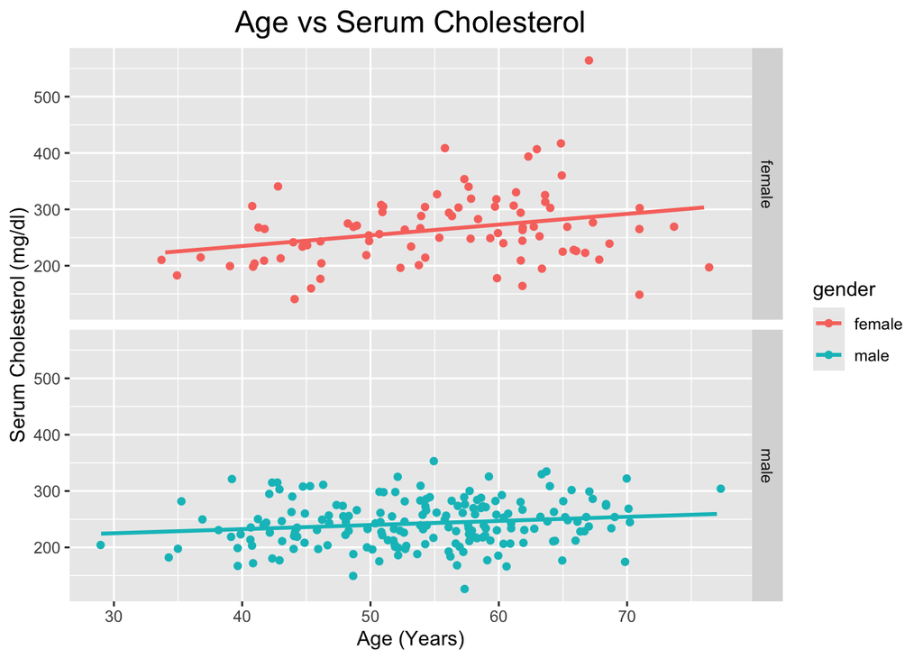

```r
heart %>%
  select(age, chol, gender) %>%
  ggplot(aes(x=age, y= chol, color= gender))+
  geom_jitter()+
  facet_grid(gender~.)+
  geom_smooth(method=lm,se=F)+
  labs(,title= "Age vs Serum Cholesterol",
       x="Age (Years)",
       y= "Serum Cholesterol (mg/dl)") +
  theme(plot.title=element_text(size=rel(1.5),hjust=0.5))
```

Problem 8. (3 points) What is the range of resting blood pressure for participants by type of chest pain? Make a plot that shows this information.

trestbps= resting blood pressure cp = chest pain type

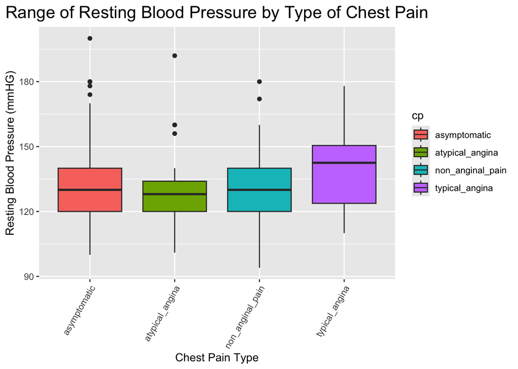

```r
heart %>%
  select(trestbps, cp) %>%
  group_by(cp) %>%
  ggplot(aes(x=cp, y= trestbps, fill = cp))+
  geom_boxplot()+
  labs(title = "Range of Resting Blood Pressure by Type of Chest Pain",
       x= "Chest Pain Type",
       y="Resting Blood Pressure (mmHG)")+
  theme(axis.text.x=element_text(angle = 60, hjust=1))+
  theme(plot.title=element_text(size=rel(1.5),hjust=0.5))
```

Problem 9. (4 points) What is the distribution of maximum heart rate achieved, separated by gender and whether or not the patient has heart disease? Make a plot that shows this information- you must use faceting.

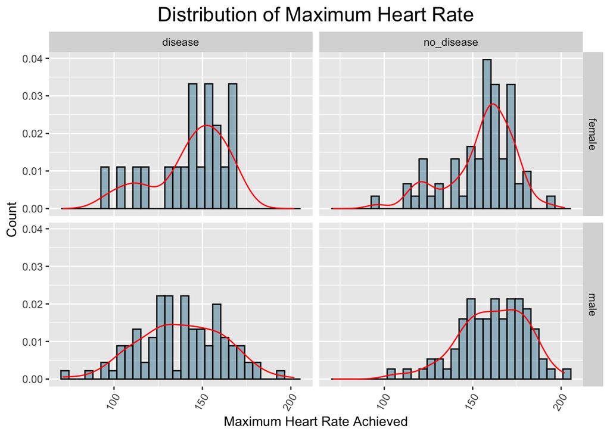

```r
heart %>%
  select(gender, thalach, target) %>%
  ggplot(aes(x=thalach))+
  geom_histogram(aes(y = after_stat(density)), fill = "deepskyblue4", alpha = 0.4, color = "black")+
  geom_density(color = "red")+
  facet_grid(gender~target)+
  labs(title = "Distribution of Maximum Heart Rate",
       x= "Maximum Heart Rate Achieved",
       y="Count")+
  theme(axis.text.x = element_text(angle = 60, hjust=1))+
  theme(plot.title=element_text(size=rel(1.5),hjust=0.5))
```

Problem 10. (4 points) What is the range of ST depression (oldpeak) by the number of major vessels colored by fluoroscopy (ca)? Make a plot that shows this relationship. (hint: should ca be a factor or numeric variable?)

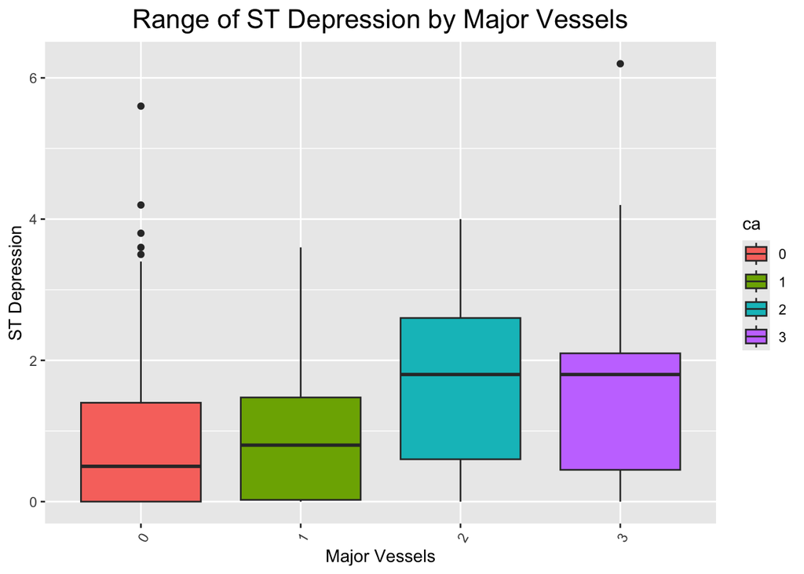

```r
heart %>%
  select(oldpeak, ca) %>%
  mutate(ca = as.factor(ca)) %>%
  group_by(ca) %>%
  ggplot(aes(x=ca, y=oldpeak, fill=ca))+
  geom_boxplot()+
  labs(title = "Range of ST Depression by Major Vessels",
       x= "Major Vessels",
       y="ST Depression")+
  theme(axis.text.x = element_text(angle = 60, hjust=1))+
  theme(plot.title=element_text(size=rel(1.5),hjust=0.5))
```

Problem 11. (4 points) Is there an age group where we see increased prevalence of heart disease? Make a plot that shows the number of participants with and without heart disease by age group.

By looking at the distribution of heart disease prevelance comapred to age, people in their late 50s (58-60) have a higher prevalance of heart disease.

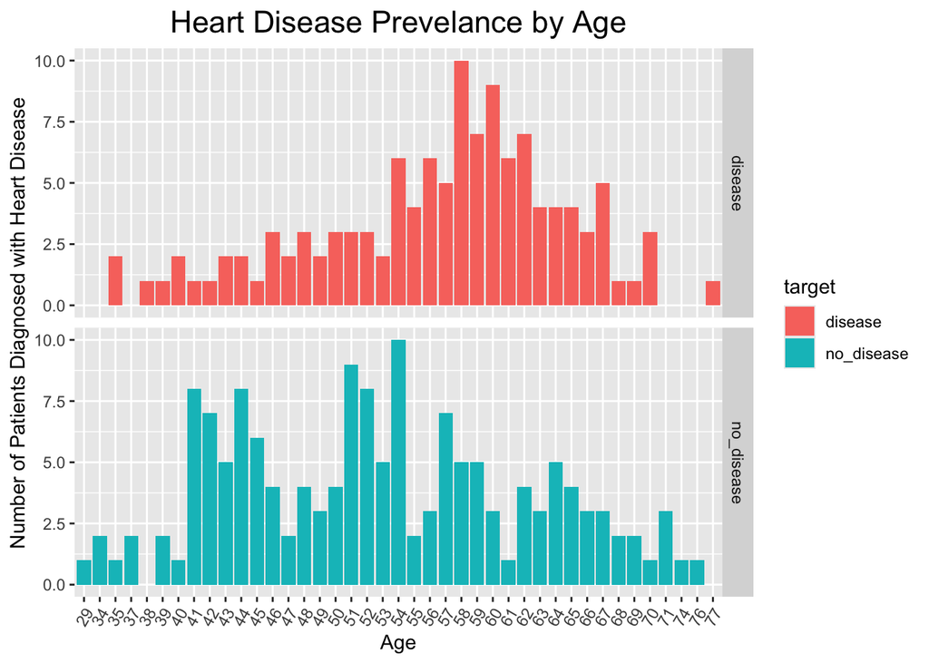

```r
heart %>%
  select(age, target) %>%
  mutate(age = as.factor(age)) %>%
  group_by(age) %>%
  arrange(desc(age)) %>%
  ggplot(aes(x=age, fill = target))+
  geom_bar()+
  facet_grid(target~.)+
  labs(title = "Heart Disease Prevelance by Age",
       x= "Age",
       y="Number of Patients Diagnosed with Heart Disease")+
  theme(axis.text.x = element_text(angle = 60, hjust=1))+
  theme(plot.title=element_text(size=rel(1.5),hjust=0.5))
```

## Submit the Midterm

1. Save your work and knit the .rmd file.
2. Open the .html file and “print” it to a .pdf file in Google Chrome (not Safari).
3. Go to the class Canvas page and open Gradescope.
4. Submit your .pdf file to the midterm assignment- be sure to assign the pages to the correct questions.
5. Commit and push your work to your repository.